# A7

Author

Carol

Published

February 27, 2026

```r
library("dplyr")
library("ggplot2")
```

# Loading Data

```r
dataset <- read.csv("/Users/carol/Desktop/2025Winter/info201/Assignment/ks-projects-201801.csv")
```

# Processing Data

```r
data <- dataset |>
  mutate(deadline_date = as.Date(deadline),
       launched_date = as.Date(launched),

       deadline_year = format(deadline_date, "%Y"),
       launched_year = format(launched_date, "%Y")
  )
glimpse(data)
```

```
Rows: 378,661
Columns: 19
$ ID               <int> 1000002330, 1000003930, 1000004038, 1000007540, 10000…
$ name             <chr> "The Songs of Adelaide & Abullah", "Greeting From Ear…
$ category         <chr> "Poetry", "Narrative Film", "Narrative Film", "Music"…
$ main_category    <chr> "Publishing", "Film & Video", "Film & Video", "Music"…
$ currency         <chr> "GBP", "USD", "USD", "USD", "USD", "USD", "USD", "USD…
$ deadline         <chr> "2015-10-09", "2017-11-01", "2013-02-26", "2012-04-16…
$ goal             <dbl> 1000, 30000, 45000, 5000, 19500, 50000, 1000, 25000, …
$ launched         <chr> "2015-08-11 12:12:28", "2017-09-02 04:43:57", "2013-0…
$ pledged          <dbl> 0.00, 2421.00, 220.00, 1.00, 1283.00, 52375.00, 1205.…
$ state            <chr> "failed", "failed", "failed", "failed", "canceled", "…
$ backers          <int> 0, 15, 3, 1, 14, 224, 16, 40, 58, 43, 0, 100, 0, 0, 7…
$ country          <chr> "GB", "US", "US", "US", "US", "US", "US", "US", "US",…
$ usd.pledged      <dbl> 0.00, 100.00, 220.00, 1.00, 1283.00, 52375.00, 1205.0…
$ usd_pledged_real <dbl> 0.00, 2421.00, 220.00, 1.00, 1283.00, 52375.00, 1205.…
$ usd_goal_real    <dbl> 1533.95, 30000.00, 45000.00, 5000.00, 19500.00, 50000…
$ deadline_date    <date> 2015-10-09, 2017-11-01, 2013-02-26, 2012-04-16, 2015…
$ launched_date    <date> 2015-08-11, 2017-09-02, 2013-01-12, 2012-03-17, 2015…
$ deadline_year    <chr> "2015", "2017", "2013", "2012", "2015", "2016", "2014…
$ launched_year    <chr> "2015", "2017", "2013", "2012", "2015", "2016", "2014…
```

# Initial Calculations

```r
total_projects <- nrow(data)
successful_projects <- data |>
  filter(state == "successful") |>
  nrow()
failed_projects <- data |>
  filter(state == "failed") |>
  nrow()
percentage_failed <- (failed_projects / total_projects) * 100
```

There are a total of 378661 projects in the dataset. Among these, 133956 projects were marked as “successful”, while 197719 projects were marked as “failed”. This means that approximately 52.22% of the projects are marked as “failed”.

# Biggest Non-Success

```r
biggest_non_success <- data |>
  filter(state != "successful") |>
  filter(usd_pledged_real == max(usd_pledged_real, na.rm = TRUE))
```

# Project State

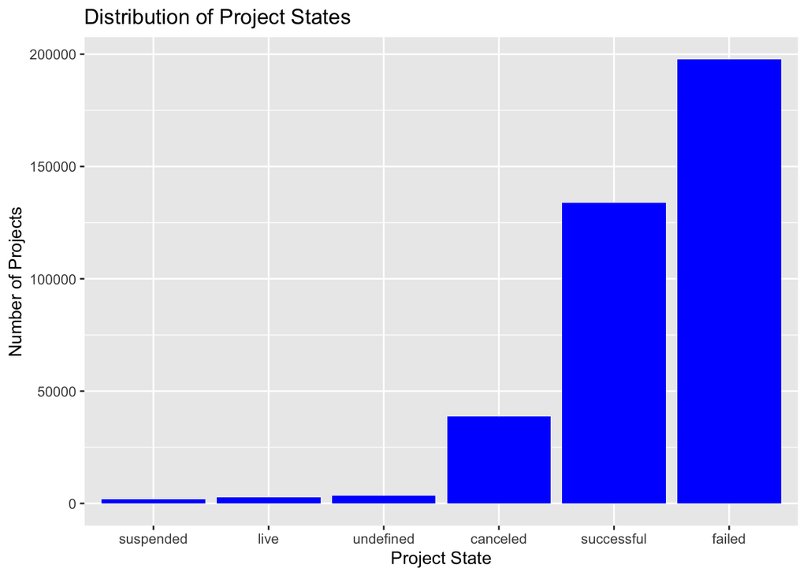

```r
state_summary <- data |>
  group_by(state) |>
  summarize(count = n())

ggplot(data = state_summary, aes(x = reorder(state, count), y = count)) +
  geom_col(fill = "blue") +
  labs(
    title = "Distribution of Project States",
    x = "Project State",
    y = "Number of Projects"
  )
```

# Yearly Summary

```r
year_summary <- data |>
  group_by(launched_year) |>
  summarize(
    count = n(),
    percent_sucess = (sum(state == "sucessful", na.rm = TRUE)/ n()) * 100,
    median_pledged = median(usd_pledged_real, na.rm = TRUE)
  )
print(year_summary)
```

```
# A tibble: 11 × 4
   launched_year count percent_sucess median_pledged
   <chr>         <int>          <dbl>          <dbl>
 1 1970              7              0            0
 2 2009           1329              0          580
 3 2010          10519              0          780
 4 2011          26237              0         1021
 5 2012          41165              0         1128
 6 2013          44851              0         1453
 7 2014          67745              0          420
 8 2015          77300              0          222
 9 2016          57184              0          501
10 2017          52200              0          632
11 2018            124              0           54.3
```

I chose to use “launched_year” because it represents the time when the project creators actually initiated their campaigns and interacted with the community, which is more relevant for analyzing trends than the deadline year. I defined “percent_success” as the number of “successful” projects divided by the total number of projects launched that year. I chose this because it gives a broad view of the overall health of the Kickstarter ecosystem rather than just comparing it to failed projects. I used “median_pledged” because the median is less sensitive to extreme “outliers” (projects that raised millions) than the mean, providing a more realistic picture of what a typical project raised.

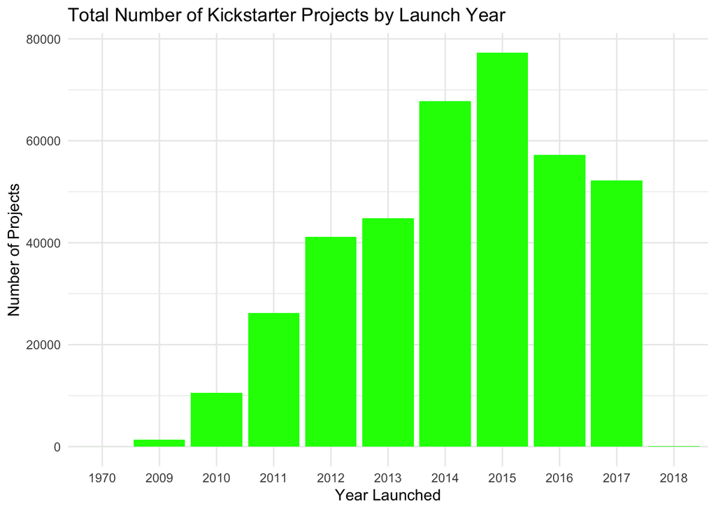

```r
ggplot(data = year_summary, aes(x = launched_year, y = count)) +
  geom_col(fill = "green") +
  labs(
    title = "Total Number of Kickstarter Projects by Launch Year",
    x = "Year Launched",
    y = "Number of Projects"
  ) +
  theme_minimal()
```

What one guess you have about what those values might mean or why they might be there or be missing？ I suspect these values represent missing data or system errors related to “Unix time.” In computing, time is often tracked as the number of seconds since January 1, 1970. If a project’s launch timestamp was recorded as 0 due to a database error, the as.Date() function would automatically convert it to 1970/01/01.

At least one follow up question you would want to ask the dataset creators about for these values？ Were the 1970 launch dates caused by a default null value in the original database, or did an error occur during the web-scraping process that reset those specific timestamps to zero?